# Omnipath Query

Daniele Capocefalo

# Get Knowledge-Base derived GRNs from Omnipath (R) and dynamically visualize networks

## Introduction

In this lecture, we will attempt to estimate Transcription Factor Activity from [a high-quality single-cell RNASeq Transcriptomic Data of Human Neocortical Development during Mid-gestation](https://www.sciencedirect.com/science/article/pii/S0896627319305616?via%3Dihub).

To Do so, we will first retrieve high quality data of Gene Regulatory Networks available in literature through [OmniPathDB](https://omnipathdb.org/) ([here](https://www.nature.com/articles/nmeth.4077) the link to the main paper).

OmniPath is a database that stores several molecular biology information of different types from a plethora of databases, from protein-interaction to gene annotation. It has both an [R](https://www.bioconductor.org/packages/release/bioc/html/OmnipathR.html) and a [python](https://github.com/saezlab/pypath) interface.

For this tutorial, we will use the R version (mainly because `pypath`, the python interface, requires a different python version that the one installed during this course), but I recommend you go check their python interface if interested. in using it for your research questions :).

- We will first use `OmnipathR` to query a database of high quality, manually curated TF -> Target interactions, also developed by the Saez-Rodriguez Lab: [DoRoTHea](https://genomebiology.biomedcentral.com/articles/10.1186/s13059-020-1949-z).
- To enrich our regulons, We will add other TF -> Target pairs from [SIGNOR](https://signor.uniroma2.it/), another database storing manualy curated TF -> Target pairs
- We will graphically visualize a couple of relevant regulons to check the contributions of each database to the regulons.
- We will then use these knowledge-base networks derived in DoRothea to check how these networks can be used toc infer TF activity with [DecoupleR](https://saezlab.github.io/decoupleR/), and how the activity of some relevant regulons can be compared to GRNs that were derived directly from the expression dataset (in the next notebook)

### Load Libraries

```r
library(OmnipathR)
library(tidyr)
library(dplyr)
library(stringr)
# we also install the visNetwork package for visualizing our Gene regulatory networks later on since we don't have cytoscape
#install.packages('visNetwork') to be installed  during the course
library(visNetwork)
library(tibble)
```

## Build a Regulon Activity Dataset with OmniPath

Omnipath stores several databases that can be used for several purposes, from general annotation to gathering insights on your sequencing data.

For example, we can use it to rebuold protein-protein interactions across all the proteins that are expressed in a given scRNA-Seq cluster

Here’s a quick overview of all the databases that are indexed by the OmniPath Team:

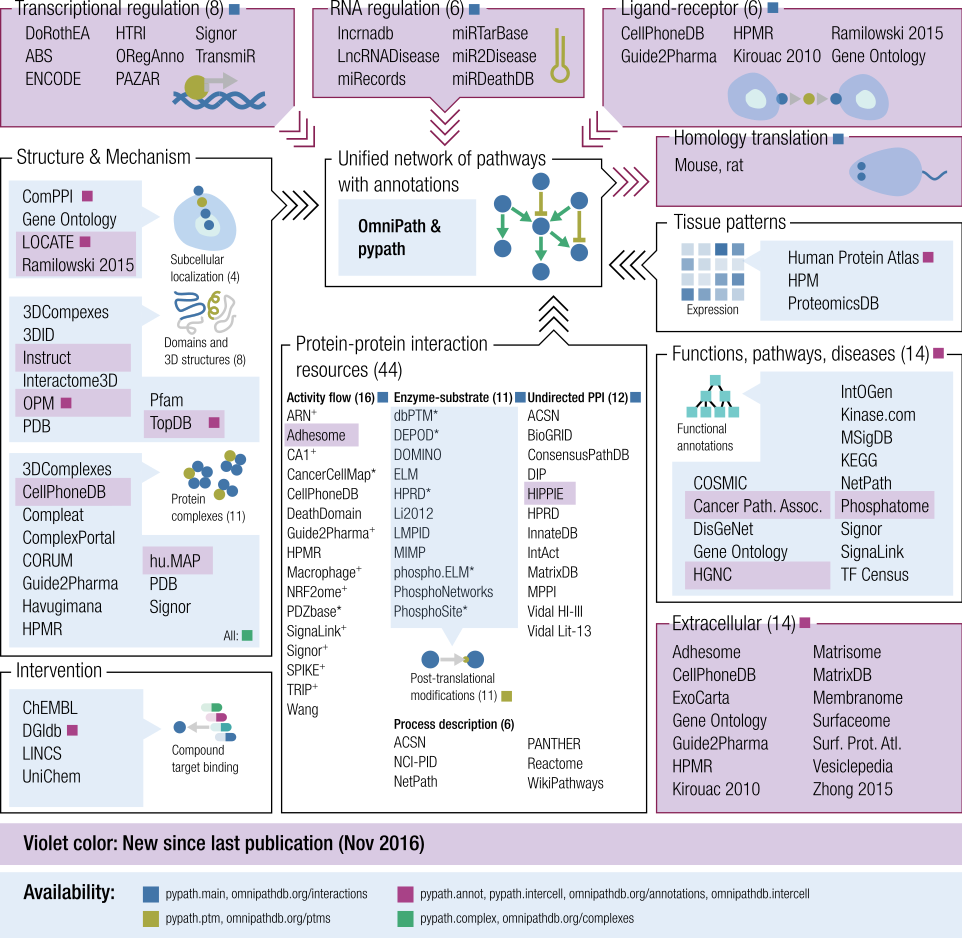

we can also check all the available database by doing:

```r
# all interaction resources
tibble(get_interaction_resources(dataset = NULL))
```

```
## # A tibble: 139 × 1
##    `get_interaction_resources(dataset = NULL)`
##    <chr>
##  1 ABS
##  2 ACSN
##  3 ACSN_SignaLink3
##  4 Adhesome
##  5 AlzPathway
##  6 ARACNe-GTEx_DoRothEA
##  7 ARN
##  8 Baccin2019
##  9 BEL-Large-Corpus_ProtMapper
## 10 BioGRID
## # … with 129 more rows
```

```r
# all annotations
tibble(get_annotation_resources(dataset = NULL))
```

```
## # A tibble: 76 × 1
##    `get_annotation_resources(dataset = NULL)`
##    <chr>
##  1 Adhesome
##  2 Almen2009
##  3 Baccin2019
##  4 CancerDrugsDB
##  5 CancerGeneCensus
##  6 CancerSEA
##  7 CellCall
##  8 CellCellInteractions
##  9 CellChatDB
## 10 CellChatDB_complex
## # … with 66 more rows
```

The website also offer a set of workflows to give you an idea of the potential of using a comprehensive knowledge base, [check this page](https://workflows.omnipathdb.org/) for more details (outside the scope of this lecture)

### Load TFs annotation

We first load through Omnipath a comprehensive, manually curated annotation of human TFs using the [TF Census Dataset](https://saezlab.github.io/OmnipathR/reference/tfcensus_download.html) and save it to retain only TFs that are fully reliable.

```r
tfs <- tfcensus_download()
# let's parse the table a little bit
names(tfs) <- gsub(" ", "_", names(tfs))
tfs <- tfs %>% distinct(HGNC_symbol) #remove duplicated TYF names or suprious anotations
tfs
```

```
## # A tibble: 1,835 × 1
##    HGNC_symbol
##    <chr>
##  1 NFYA
##  2 ARX
##  3 HOXA11
##  4 SOX8
##  5 ZFX
##  6 DLX6
##  7 ETV1
##  8 PAX6
##  9 TEAD3
## 10 E2F2
## # … with 1,825 more rows
```

```r
write.table(tfs, file = 'data/TFCensus_human.tsv', sep = '\t', row.names = F, quote = F)
```

### Retrieve TF Target interaction of high quality from DoRothEA

DoRothEA contains a list of several TF -> Target interactions. All these interactions are assigned a confidence level that goes from **A** (very high quality TF-> Target interactions) to **E** (poorly annotated interaction)

We want to retain the highest amount of information possible while pruning the possible ‘faux’ interactions, i.e., gene regulatory relationships that has been proven only by one paper or by high-throughput sequencing. Let’s query omnipath with the `import_dorothea_interactions` method

[output not shown]

We want to retain only direct TF -> Target interaction (`is_directed` column must be 1) and retain only interactions that have a consensus across the different sources that were used to curate the annotation

We also remove some columns and put a `1` whether the interaction is a stimulation and `-1` if the direction is an inhibition Let’s go!

```r
dorothea_filtered <- dorothea %>% filter(is_directed == 1, consensus_direction ==1)  %>% mutate(regulation = case_when(is_inhibition == 1 ~ -1, is_stimulation == 1 ~ 1)) %>% filter(source_genesymbol %in% tfs$HGNC_symbol) %>% select(source_genesymbol, target_genesymbol, regulation) %>% mutate(source = 'dorothea')
dorothea_filtered
```

```
## # A tibble: 3,033 × 4
##    source_genesymbol target_genesymbol regulation source
##    <chr>             <chr>                  <dbl> <chr>
##  1 AHR               CYP1A1                     1 dorothea
##  2 AHR               CYP1B1                     1 dorothea
##  3 AR                AKR1C3                    -1 dorothea
##  4 AR                AKT1                       1 dorothea
##  5 AR                CDC6                       1 dorothea
##  6 AR                CDH2                       1 dorothea
##  7 AR                CDKN1A                     1 dorothea
##  8 AR                DBI                        1 dorothea
##  9 AR                DDT                        1 dorothea
## 10 AR                DHX15                      1 dorothea
## # … with 3,023 more rows
```

```r
# save the dataframe
write.table(dorothea_filtered, 'data/dorothea_filtered.tsv', quote =  F, sep = '\t', row.names = F)
```

### Query SIGNOR

[SIGNOR](https://signor.uniroma2.it/) is a database that stores manually curated causal relationships across proteins of different organisms. Among these relationships, there are also regulatory interactions we might want to add to our database.

We can query Omnipath and retrieve such interactions as follows:

```r
signor <- tibble(import_all_interactions(resources = c('SIGNOR'),organism = 9606))
signor
```

```
## # A tibble: 14,186 × 17
##    source target sourc…¹ targe…² is_di…³ is_st…⁴ is_in…⁵ conse…⁶ conse…⁷ conse…⁸
##    <chr>  <chr>  <chr>   <chr>     <dbl>   <dbl>   <dbl>   <dbl>   <dbl>   <dbl>
##  1 Q13976 Q13507 PRKG1   TRPC3         1       0       1       1       0       1
##  2 Q13976 Q9HCX4 PRKG1   TRPC7         1       1       0       1       1       0
##  3 Q13438 Q9HBA0 OS9     TRPV4         1       1       1       1       1       1
##  4 P18031 Q9H1D0 PTPN1   TRPV6         1       0       1       1       0       1
##  5 P63244 Q9BX84 RACK1   TRPM6         1       0       1       1       0       1
##  6 P17612 Q9GZU1 PRKACA  MCOLN1        1       0       1       1       0       1
##  7 Q16539 P49137 MAPK14  MAPKAP…       1       1       0       1       1       0
##  8 P49137 Q13151 MAPKAP… HNRNPA0       1       1       0       1       1       0
##  9 P49137 O95453 MAPKAP… PARN          1       0       1       1       0       1
## 10 O60674 P19235 JAK2    EPOR          1       1       0       1       1       0
## # … with 14,176 more rows, 7 more variables: type <chr>, dorothea_level <chr>,
## #   sources <chr>, references <chr>, curation_effort <dbl>, n_references <chr>,
## #   n_resources <int>, and abbreviated variable names ¹source_genesymbol,
## #   ²target_genesymbol, ³is_directed, ⁴is_stimulation, ⁵is_inhibition,
## #   ⁶consensus_direction, ⁷consensus_stimulation, ⁸consensus_inhibition
```

As before, let’s filter the dataset and produce a cleaned table

```r
signor_filtered <- signor %>% filter(is_directed == 1, consensus_direction ==1)  %>% mutate(regulation = case_when(is_inhibition == 1 ~ -1, is_stimulation == 1 ~ 1)) %>% filter(source_genesymbol %in% tfs$HGNC_symbol) %>% select(source_genesymbol, target_genesymbol, regulation) %>% mutate(source = 'SIGNOR')
signor_filtered
```

```
## # A tibble: 1,119 × 4
##    source_genesymbol target_genesymbol regulation source
##    <chr>             <chr>                  <dbl> <chr>
##  1 TERF2             ATM                       -1 SIGNOR
##  2 TP53              BIRC5                     -1 SIGNOR
##  3 NFKB1             MAP3K8                    -1 SIGNOR
##  4 TP53              BCL2                      -1 SIGNOR
##  5 SETDB2            H3C8                      -1 SIGNOR
##  6 DOT1L             H3C8                       1 SIGNOR
##  7 RCOR1             KDM1A                      1 SIGNOR
##  8 STAT6             GATA3                      1 SIGNOR
##  9 KAT5              H4-16                      1 SIGNOR
## 10 SHPRH             PCNA                      -1 SIGNOR
## # … with 1,109 more rows
```

```r
# save the dataframe
write.table(signor_filtered, 'data/signor_filtered.tsv', quote =  F, sep = '\t', row.names = F)
```

### Create a common regulon dataframe

We merge now the two dataframes and add a small tag to understand how many TfF -> Target pairs are preserved across the two databases

```r
regulons <- bind_rows(dorothea_filtered, signor_filtered)

#if two interactors of a regulon appears, add a 'common' tag
regulons_filtered <- regulons %>% group_by(source_genesymbol, target_genesymbol) %>% mutate(source = replace(source, n_distinct(source) > 1, 'both')) %>% filter(source == max(source)) %>% distinct() %>% arrange(source_genesymbol, target_genesymbol) %>% filter(str_count(target_genesymbol, "_") < 1) %>% ungroup()

regulons_filtered
```

```
## # A tibble: 3,912 × 4
##    source_genesymbol target_genesymbol regulation source
##    <chr>             <chr>                  <dbl> <chr>
##  1 ADNP              CTCF                      -1 SIGNOR
##  2 ADNP              CTNNB1                     1 SIGNOR
##  3 ADNP              MAP1LC3B                   1 SIGNOR
##  4 AHR               CYP1A1                     1 both
##  5 AHR               CYP1B1                     1 both
##  6 AKAP8             PRKACA                     1 SIGNOR
##  7 AKAP8L            DHX9                       1 SIGNOR
##  8 ANAPC2            DVL1                      -1 SIGNOR
##  9 AR                AKR1C3                    -1 dorothea
## 10 AR                AKT1                       1 dorothea
## # … with 3,902 more rows
```

```r
# count the number of unique and common regulons
table(regulons_filtered$source)
```

```
##
##     both dorothea   SIGNOR
##      162     2848      902
```

```r
write.table(regulons_filtered, 'data/regulons_human.tsv', sep = '\t', row.names = F, quote = F)
```

### Investigate our knwledge-base GRN understand how Relevant Regulons in Neuron Differentiation are present

Let’s now visualize some of these regulons with the [visNetwork](https://datastorm-open.github.io/visNetwork/) package.

We first load a handful of Relevant TFs that we know having some involvement in different cell populations

```r
relevant_tfs <- tibble(population = c(rep('Progenitor', 3), rep('Immature_Excitatory', 4), rep('Excitatory_Neurons', 4)), TF = c('PAX6', 'FOS', 'SOX2', 'EOMES', 'ETV2', 'ETV3', 'ETV4', 'BLC11A', 'BCL11B', 'CUX1', 'CUX2'))
relevant_tfs
```

```
## # A tibble: 11 × 2
##    population          TF
##    <chr>               <chr>
##  1 Progenitor          PAX6
##  2 Progenitor          FOS
##  3 Progenitor          SOX2
##  4 Immature_Excitatory EOMES
##  5 Immature_Excitatory ETV2
##  6 Immature_Excitatory ETV3
##  7 Immature_Excitatory ETV4
##  8 Excitatory_Neurons  BLC11A
##  9 Excitatory_Neurons  BCL11B
## 10 Excitatory_Neurons  CUX1
## 11 Excitatory_Neurons  CUX2
```

```r
#write.table(relevant_tfs, 'data/Fetal_Brain_TFs.tsv', sep = '\t', quote = F, row.names = F)
```

How many of these regulons are in our knowledge base regulatory network? how many targets do they have?

```r
relevant_regulons <- regulons_filtered %>% filter(source_genesymbol %in% relevant_tfs$TF)
relevant_regulons %>% group_by(source_genesymbol) %>% count()
```

```
## # A tibble: 7 × 2
## # Groups:   source_genesymbol [7]
##   source_genesymbol     n
##   <chr>             <int>
## 1 CUX1                  3
## 2 CUX2                  1
## 3 ETV3                  3
## 4 ETV4                  7
## 5 FOS                  25
## 6 PAX6                  3
## 7 SOX2                  5
```

We can see that , with the exception of FOS, that is a well-studied TF involved in cell proliferation and differentiation, there is not so much information on the TFs we are looking for.

Let’s see now how they are related to each other by drawing the network of these regulons

```r
# create node dataframe and add customizartion
sources <- relevant_regulons %>% distinct(source_genesymbol) %>% rename(label = source_genesymbol)
destinations <- relevant_regulons %>% distinct(target_genesymbol) %>% rename(label = target_genesymbol)
nodes <- full_join(sources, destinations, by = "label")
nodes <- rowid_to_column(nodes, "id")
nodes_viz <- nodes %>% mutate(shape = if_else(label %in% relevant_regulons$source_genesymbol, 'diamond', 'circle')) %>% mutate(color = if_else(label %in% relevant_regulons$source_genesymbol, 'red', 'lightgreen'))
nodes_viz
```

```
## # A tibble: 52 × 4
##       id label   shape   color
##    <int> <chr>   <chr>   <chr>
##  1     1 CUX1    diamond red
##  2     2 CUX2    diamond red
##  3     3 ETV3    diamond red
##  4     4 ETV4    diamond red
##  5     5 FOS     diamond red
##  6     6 PAX6    diamond red
##  7     7 SOX2    diamond red
##  8     8 ECT2    circle  lightgreen
##  9     9 PIK3IP1 circle  lightgreen
## 10    10 RACGAP1 circle  lightgreen
## # … with 42 more rows
```

```r
#add edges customization
per_route <- relevant_regulons %>% rename(weight = regulation) %>% mutate(color = case_when(source == 'SIGNOR' ~ 'red', source == 'dorothea' ~ 'green', source == 'both' ~ 'blue')) %>% mutate(arrows = 'to') %>% mutate(dashes = ifelse(weight > 0, FALSE, TRUE))
per_route
```

```
## # A tibble: 47 × 7
##    source_genesymbol target_genesymbol weight source   color arrows dashes
##    <chr>             <chr>              <dbl> <chr>    <chr> <chr>  <lgl>
##  1 CUX1              ECT2                  -1 dorothea green to     TRUE
##  2 CUX1              PIK3IP1               -1 SIGNOR   red   to     TRUE
##  3 CUX1              RACGAP1               -1 dorothea green to     TRUE
##  4 CUX2              OGG1                   1 SIGNOR   red   to     FALSE
##  5 ETV3              DDX20                 -1 SIGNOR   red   to     TRUE
##  6 ETV3              DUSP6                 -1 SIGNOR   red   to     TRUE
##  7 ETV3              NFKB1                 -1 dorothea green to     TRUE
##  8 ETV4              AGTR1                  1 dorothea green to     FALSE
##  9 ETV4              ERBB2                 -1 dorothea green to     TRUE
## 10 ETV4              ETS1                   1 dorothea green to     FALSE
## # … with 37 more rows
```

```r
edges <- per_route %>%
  left_join(nodes, by = c("source_genesymbol" = "label")) %>%
  rename(from = id)

edges <- edges %>%
  left_join(nodes, by = c("target_genesymbol" = "label")) %>%
  rename(to = id)
```

```r
visNetwork(nodes_viz, edges, width = "100%", height = 750 ) %>% visOptions(highlightNearest = TRUE) %>%   addFontAwesome() %>% visLegend(useGroups = F,addNodes = data.frame(label = c('TF', 'Target'), shape = c('diamond', 'circle'), color = c('red', 'lightgreen')), addEdges = data.frame(label = c('dorothea', 'SIGNOR', 'both', 'activation', 'inhibition'), color = c('green', 'red', 'blue', 'black', 'black'), dashes = c(FALSE, FALSE, FALSE, FALSE, TRUE)))
```

[interactive chart not shown]

What does this network tell us?

Let’s export the dataset

```r
write.table(relevant_regulons, 'data/human_relevant_regulons.tsv', sep = '\t', quote = F, row.names = F)
```